# R Notebook

Loadin the libraries

```r
library(CodeClanData)
library(ggplot2)
```

Take the data in the dataset qb_revenue_breakdown and make a stacked bar chart showing the sources of revenue across the two years in the dataset.

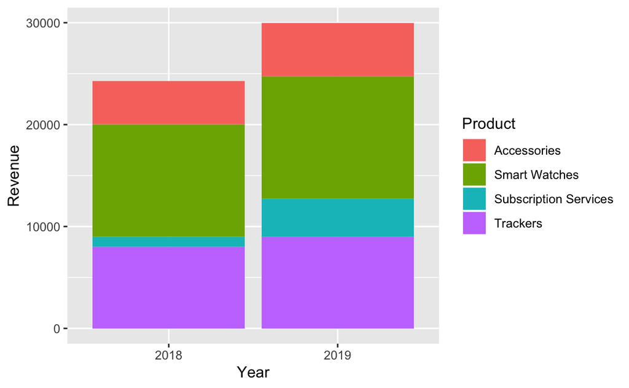

```r
ggplot(qb_revenue_breakdown) +
  aes(x = Year, y = Revenue, fill = Product) +
  geom_bar(stat = "identity")
```

Make a line chart showing monthly sales of the “flagship product” - the KwikBit Unit1 - over the last year. This data is inside qb_monthly_sales, but you will need to use subset.

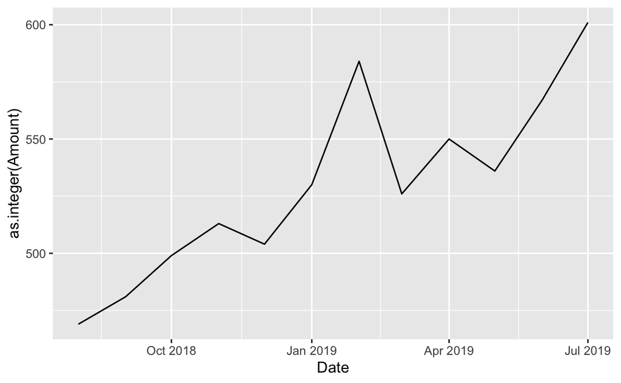

```r
ggplot(subset(qb_monthly_sales, Cashflow == "Kwikbit Unit 1 Sales")) +
  aes(x = Date, y = as.integer(Amount)) +
  geom_line()
```

Make a line chart showing monthly revenue and costs over the last year. This data is also in qb_monthly_sales.

```r
separated_data <- subset(qb_monthly_sales,
                 qb_monthly_sales$Cashflow == "Kwikbit Unit 1 Sales")
cost <- subset(qb_monthly_sales,
                 qb_monthly_sales$Cashflow == "Cost")
revenue <- subset(qb_monthly_sales,
                 qb_monthly_sales$Cashflow == "Total Revenue")
separated_data$cost <- cost$Amount
separated_data$revenue <- revenue$Amount
```

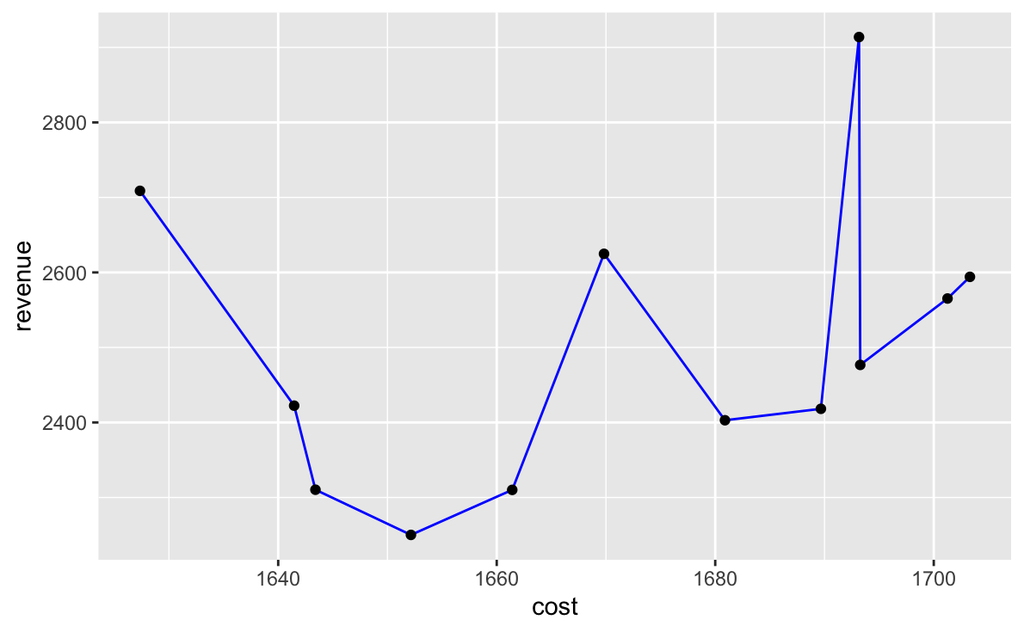

```r
ggplot(separated_data) +
  aes(x = cost, y = revenue) +
  geom_line(colour = "blue") +
  geom_point(colour = "black")
```

4.2 Potential Personal fitness trackers are a growth industry. One company does not dominate the field. Show annual sales of personal fitness trackers over the last 5 years broken down by company as a ribbon plot (use geom_area). This data is in qb_competitors.

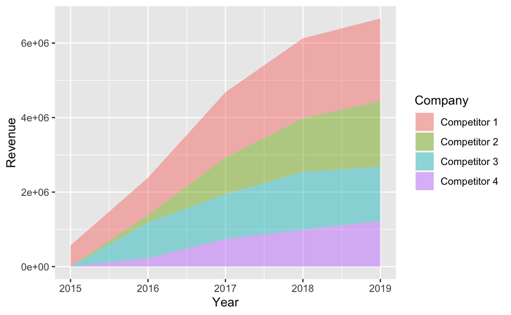

```r
ggplot(qb_competitors) +
  aes(x = Year, y = Revenue, fill = Company) +
  geom_area(alpha = 0.45)
```

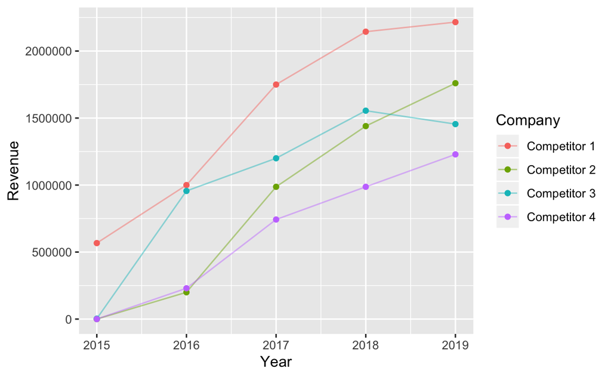

```r
ggplot(qb_competitors) +
  aes(x = Year, y = Revenue, colour = Company) +
  geom_line(alpha = 0.45) +
  geom_point()
```

5 Extension Try out different ways of plotting these three datasets. Which graphs do you think are particularly effective at showing QikBit’s success?

Plotting sales against revenue:

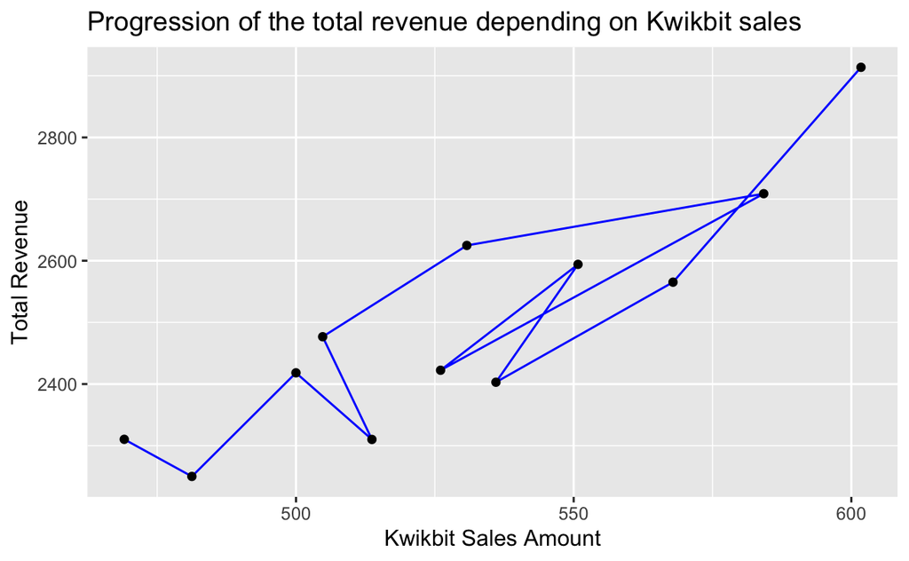

```r
ggplot(separated_data) +
  aes(x = Amount, y = revenue) +
  geom_path(colour = "blue") +
  geom_point(colour = "black") +
  labs(
    x = "Kwikbit Sales Amount",
    y = "Total Revenue",
    title = "Progression of the total revenue depending on Kwikbit sales"
  )
ggsave("Revenue_against_sales_plot.pdf")
```